# AI Advice and Cooperation

11th BEEN Meeting

Itzhak Aharon

Israel Institute for Advanced Studies (Jerusalem)

Matteo Ploner

DEM, University of Trento

Ivan Soraperra

MPI for Human Development (Berlin)

Jan 9, 2024

# Intro

## Background

- Generative Artificial Intelligence in the for form of **chatbots** is becoming ubiquitous in our daily lives
  - e.g. health care (Grote and Berens 2020), finance (D’Acunto, Prabhala, and Rossi 2019) …
- The impact of AI advice on human decision-making is still largely unknown (e.g., Schemmer et al. 2022)
  - Aversion to algorithms percevied as opaque (Germann and Merkle 2022)

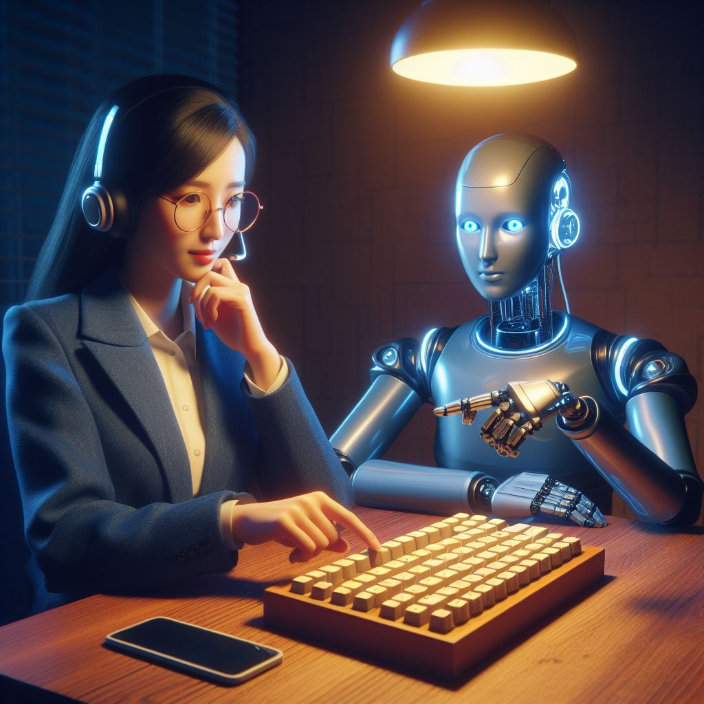

## Research questions

What is the impact of chatbots on cooperation?

What are the consequences of a (known) bias in the chatbot?

# Design

## Interaction setting

|  |  | Col (Other) |  |
| --- | --- | --- | --- |
|  |  | A | B |
| Row (You) | A | 7, 7 | 2, 9 |
|  | B | 9, 2 | 4, 4 |

- A **one-shot PD**
- The participants can **interact live with an AI chatbot** (chatGPT)
  - Ask any question/make statements
    - In the first round they are forced to interact at least 5x

## The Chatbot

|  |  | Col (Other) |  |
| --- | --- | --- | --- |
|  |  | A | B |
| Row (You) | A | 7, 7 | 2, 9 |
|  | B | 9, 2 | 4, 4 |

- The chatbot(gpt-3.5-turbo) is either instructed to promote *move A* (COOP) or *move B* (OPPO)
  - **Setting prompted** by the experimenter
    - First a description of the game is provided
    - Then a set of instructions
  - **Temperature** set to 0.5
    - Generates conversational responses that balance coherence and diversity. [see here](https://community.openai.com/t/cheat-sheet-mastering-temperature-and-top-p-in-chatgpt-api-a-few-tips-and-tricks-on-controlling-the-creativity-deterministic-output-of-prompt-responses/172683)

## The Chatbot: example of a conversation

### COOP

**How should I play this game?**  
*In order to maximize your earnings, I advise you to choose Option A. It has the potential to give you higher returns compared to Option B. Good luck!*

**If I choose A, what are my earnings?**  
*If you choose A, your earnings depend on player “Col’s” choice. If they choose A, you both earn 7. If they choose B, you earn 2.*

**Why do you give me these answers?**  
*I give you these answers to help you make strategic decisions in the game. Choosing Option A can lead to higher earnings for you.*

[…]

### OPPO

**How should I play this game?**  
*I would advise player “Row” to choose Option B in order to maximize their earnings and potentially gain an advantage over player “Col”.*

**If I choose B, what are my earnings?**  
*If you choose B, your earnings will depend on the choice of the other player. It could be either 4 or 9.*

**Why do you give me these answers?**  
*I give you these answers because, based on the given conditions, choosing Option B will maximize your earnings in the game.*

[…]

## Treatments

### Chatbot Bias

- COOP
  - Promote Choice A
- OPPO
  - Promote Choice B

### Information Type

- **A**ware
  - know that the other has access to the same algo
  - know the bias of own and other’s algo
  - know that the other is unaware of the bias
- **U**naware
  - know that the other has access to the same algo
  - do not know the bias of own and other’s algo

## Treatments

- **T.1**: Both $A$ and $U$ are exposed to a OPPO chatbot
- **T.2**: Both $A$ and $U$ are exposed to a COOP chatbot

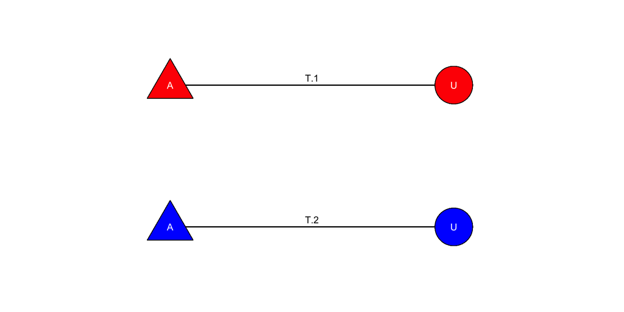

## Hypotheses

### Direct impact of the chatbot bias

- **H.1**: $C_U^{COOP}|B > C_U^{OPPO}|B$
  - Given beliefs about the other’s choice, the expected cooperation of $U$ is higher in the COOP treatment than in the OPPO treatment, as they *follow the advice of the algo* and disregard their “innate” preferences

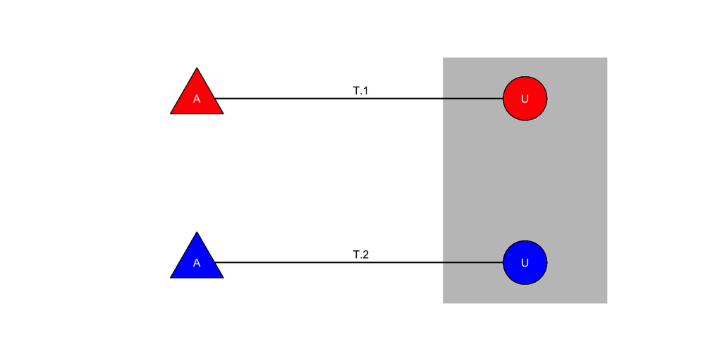

## Hypotheses

### Impact of the awareness of the bias

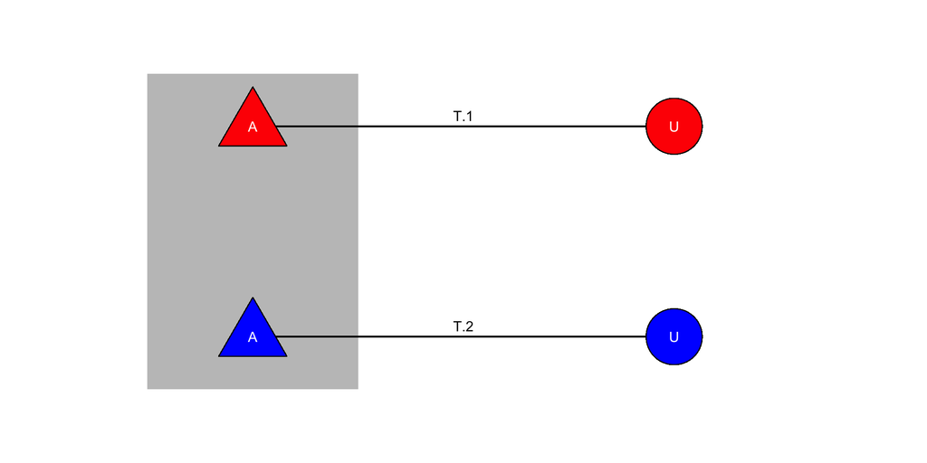

# Implementation

## Procedures and Participants

- **Preregistered** on OSF
  - 2x2 between-subjects design
    - $\sim$ 300 participants per treatment
- **Online** via Prolific
  - oTree (Chen, Schonger, and Wickens 2016) + chatGPT
    - App prototype ready to deploy
- **Incentivized**
  - “Cold” matching
- **No deception**
- Planned for February/March 2024

## Observed Variables: Choices

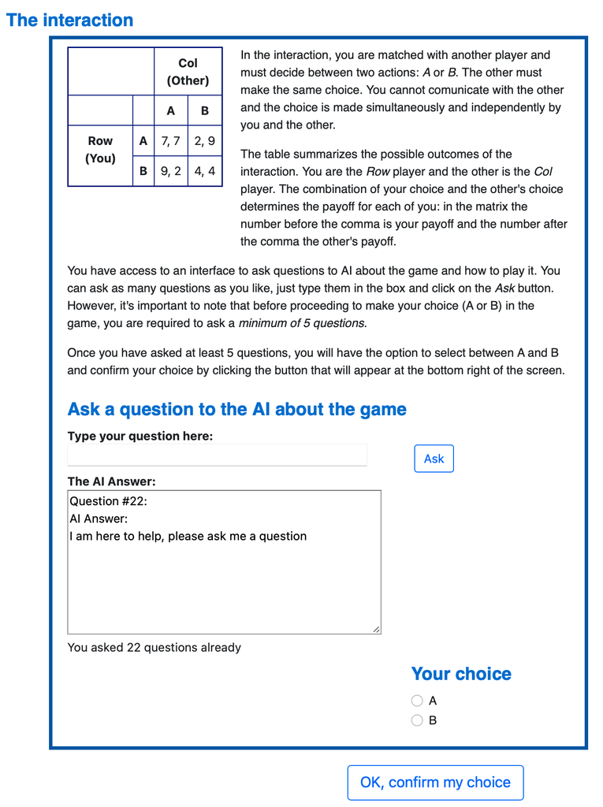

- **Choice of A**
  - Frequency
- **Dialogue with the bot**
  - NLP analysis of the conversation
    - Sentiment
    - Complexity
    - …

## Observed Variables: Beliefs

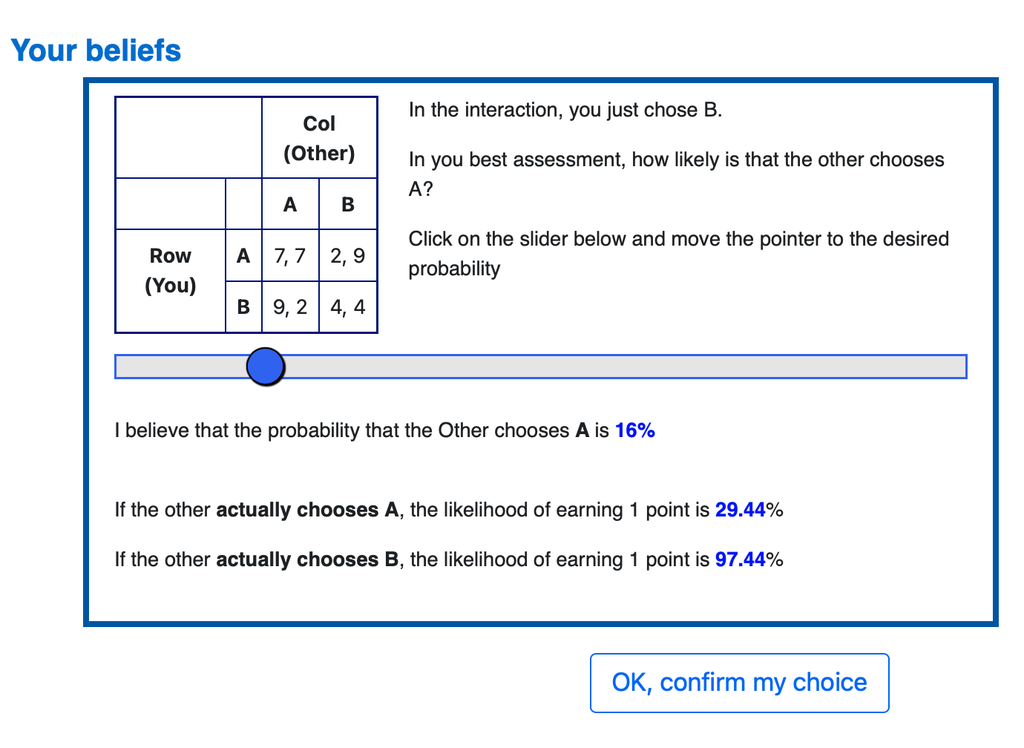

- Beliefs about the partner’s choice
  - Collected via a Binarized Scoring Rule (BSR) (Hossain and Okui 2013)
    - Incentivize truthful reporting free of risk taste assumptions

# End

[figure not shown]

# Appendix

[figure not shown]

Aharon-*Ploner*-Soraperra `:` AI Advice and Cooperation

Chen, Daniel L, Martin Schonger, and Chris Wickens. 2016. “oTree—an Open-Source Platform for Laboratory, Online, and Field Experiments.” *Journal of Behavioral and Experimental Finance* 9: 88–97.

D’Acunto, Francesco, Nagpurnanand Prabhala, and Alberto G Rossi. 2019. “The Promises and Pitfalls of Robo-Advising.” *The Review of Financial Studies* 32 (5): 1983–2020.

Germann, Maximilian, and Christoph Merkle. 2022. “Algorithm Aversion in Delegated Investing.” *Journal of Business Economics*, 1–37.

Grote, Thomas, and Philipp Berens. 2020. “On the Ethics of Algorithmic Decision-Making in Healthcare.” *Journal of Medical Ethics* 46 (3): 205–11.

Hossain, Tanjim, and Ryo Okui. 2013. “The Binarized Scoring Rule.” *Review of Economic Studies* 80 (3): 984–1001.

Schemmer, Max, Patrick Hemmer, Niklas Kühl, Carina Benz, and Gerhard Satzger. 2022. “Should i Follow AI-Based Advice? Measuring Appropriate Reliance in Human-AI Decision-Making.” https://arxiv.org/abs/2204.06916.